# AsaruSim data analysis

Comparaison real vs simulation

Ali Hamraoui

2024-09-19

## R Markdown

### 5k Human PBMCs data

IN this section, we downloaded the [5k Human PBMCs, 3’ v3.1](https://www.10xgenomics.com/datasets/5k-human-pbmcs-3-v3-1-chromium-controller-3-1-standard) count matrix and used it as input to AsaruSim. From the 5,000 cells initially present in the original matrix, we selected 3 cell types (CD8+T, CD4+T and B cells) resulting in 1,091 cells.

We load the 10X matrix

```r
pbmc.mtx <- Seurat::Read10X("data/PBMC_10X/")
dim(pbmc.mtx)
```

```
## [1] 36601  5140
```

```r
sum(pbmc.mtx)
```

```
## [1] 49412106
```

We create a Seurat object, identified clsters and cell types.

We visualize clusters and cell types

```r
pbmc.Obj
```

```
## An object of class Seurat
## 23729 features across 4880 samples within 1 assay
## Active assay: RNA (23729 features, 2000 variable features)
##  3 layers present: counts, data, scale.data
##  3 dimensional reductions calculated: pca, tsne, umap
```

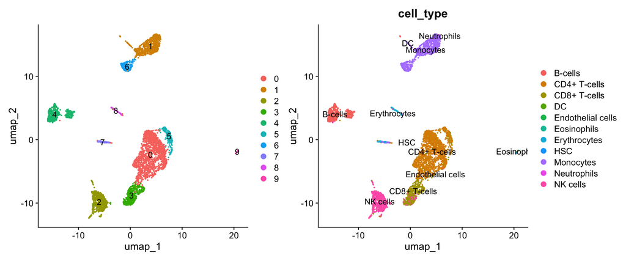

```r
Seurat::DimPlot(pbmc.Obj, reduction = "umap", label = T) | Seurat::DimPlot(pbmc.Obj, reduction = "umap", group.by = "cell_type", label = T)
```

We identified B-cells, CD4+ T-cells and CD8+ T-cells clusters.

```r
df.identities <- cbind(as.data.frame(pbmc.Obj$cell_type),
                       as.data.frame(pbmc.Obj$seurat_clusters))
colnames(df.identities) <- c("cell_type","cluster")

list.identities <- list(
B_cells = which(df.identities$cluster %in% c(4) &
                  df.identities$cell_type=="B-cells"),

T_cells = which( df.identities$cluster %in% c(5) &
                   df.identities$cell_type=="CD4+ T-cells"),

macrophages = which(df.identities$cluster %in% c(3) &
                      df.identities$cell_type=="CD8+ T-cells"))

selected.cells <- as.vector(unlist(list.identities))
selected.cells <- rownames(df.identities)[selected.cells]
```

We filter for selected cell types.

```r
pbmc.Obj[["CellName"]] <- colnames(pbmc.Obj)
sub.pbmc.Obj <- subset(pbmc.Obj, subset = CellName %in% selected.cells)
```

We re-compute clusters and visualize them.

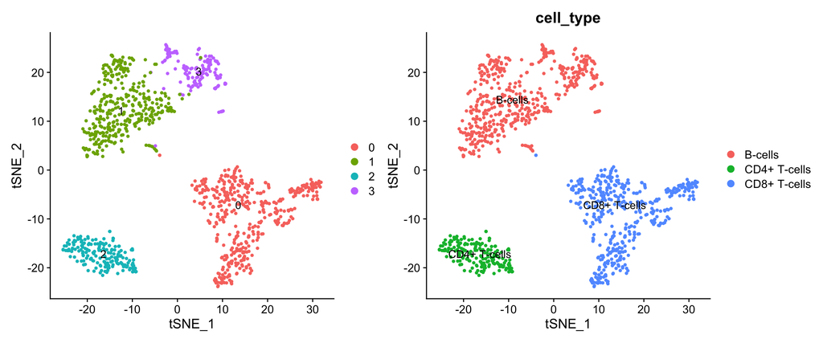

```r
sub.pbmc.Obj <- clustuerer(sub.pbmc.Obj, 200, 2000, 15)
Seurat::DimPlot(sub.pbmc.Obj, reduction = "tsne", label = T) | Seurat::DimPlot(sub.pbmc.Obj, reduction = "tsne", group.by = "cell_type", label = T)
```

We save the matrix

```r
sum(pbmc.mtx[, selected.cells])
```

```
## [1] 9686785
```

```r
pbmc.mtx_sub <- pbmc.mtx[, selected.cells]
dim(pbmc.mtx_sub)
```

```
## [1] 36601  1091
```

```r
sum(pbmc.mtx_sub)
```

```
## [1] 9686785
```

```r
write.csv(pbmc.mtx_sub, file="data/pbmc.mtx_sub_10M.csv")
```

### Comparaison: AsaruSim simulated PBMC vs real PBMC

In this section used the subset of the PBMC matrix as a template to simulate the synthetic UMI count matrix (step1). Next, we simulated 30 million perfect reads (FASTA) (step2) with 2 PCR cycles (step 3). We downloaded a subset of 1M original [FASTQ raw reads](https://www.10xgenomics.com/datasets/5k-human-pbmcs-3-v3-1-chromium-controller-3-1-standard) to generate the error model for Badread, and then introduced errors to generate the synthetic reads (FASTQ) (step4).

Next, we pre-processed the simulated raw reads using Sockeye pipeline (nanoporetech, 2023), then, both matrices were loaded and processed using Seurat v5 (Hao et al. 2024).

We reload the subseted PBBMC matrix

```r
pbmc.mtx_sub <- read.csv("data/pbmc.mtx_sub_10M.csv", row.names = 1)
dim(pbmc.mtx_sub)
```

```
## [1] 36601  1091
```

```r
sum(pbmc.mtx_sub)
```

```
## [1] 9686785
```

We load AsaruSim Marix preprocessed using Sockeye.

```r
sim.mtx <- read.csv("data/Sockeye_PBMC_3/gene_expression.counts_5prim.tsv", sep = "\t", row.names = 1)
dim(sim.mtx)
```

```
## [1] 11034  1087
```

```r
sum(sim.mtx)
```

```
## [1] 5314592
```

```r
sim.mtx <- rename_mtx_with_gene_names(sim.mtx)
```

```
## [1] "nb of Unknown gene IDs: 96"
```

We create a Seaurate object for the both datasets.

```r
real.Obj
```

```
## An object of class Seurat
## 36601 features across 1091 samples within 1 assay
## Active assay: RNA (36601 features, 2000 variable features)
##  3 layers present: counts, data, scale.data
##  3 dimensional reductions calculated: pca, tsne, umap
```

```r
sim.Obj
```

```
## An object of class Seurat
## 10938 features across 1087 samples within 1 assay
## Active assay: RNA (10938 features, 2000 variable features)
##  3 layers present: counts, data, scale.data
##  3 dimensional reductions calculated: pca, tsne, umap
```

We compared the TSNE visualisation of the both dataset.

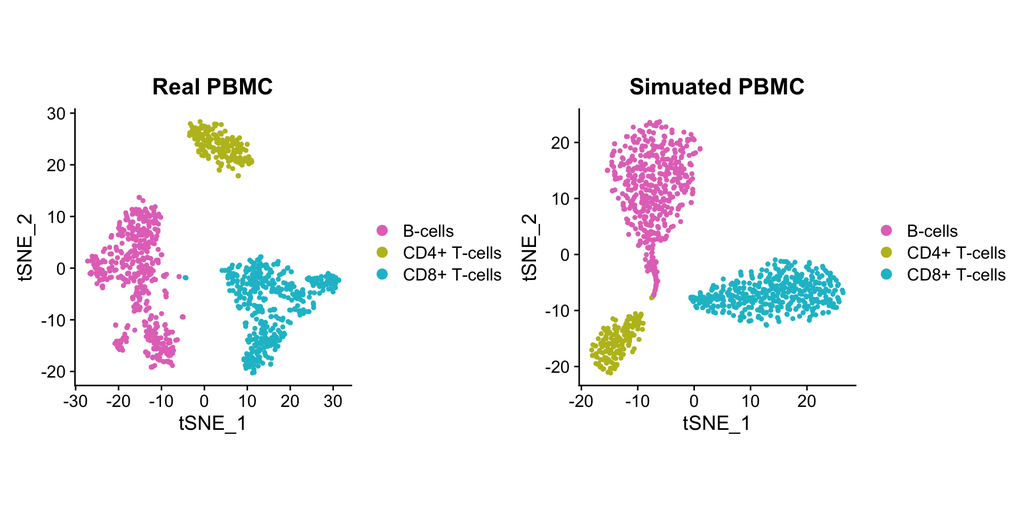

```r
real.plt <- Seurat::DimPlot(real.Obj, reduction = "tsne",  group.by = "corrected_cell_type", cols = c('#E377C2', '#BCBD22','#17BECF' )) +
    ggtitle(paste('Real PBMC'))+
    theme(aspect.ratio = 1)

sim.plt <- Seurat::DimPlot(sim.Obj, reduction = "tsne",  group.by = "corrected_cell_type", cols = c('#E377C2', '#BCBD22','#17BECF' )) +
    ggtitle(paste('Simuated PBMC'))+
    theme(aspect.ratio = 1)
real.plt | sim.plt
```

```r
B.real.markers <- FindMarkers(real.Obj, ident.1 = "B-cells", group.by = "cell_type")
CD4.real.markers <- FindMarkers(real.Obj, ident.1 = "CD4+ T-cells", group.by = "cell_type")
CD8.real.markers <- FindMarkers(real.Obj, ident.1 = "CD8+ T-cells", group.by = "cell_type")

B.sim.markers <- FindMarkers(sim.Obj, ident.1 = "B-cells", group.by = "cell_type")
CD4.sim.markers <- FindMarkers(sim.Obj, ident.1 = "CD4+ T-cells", group.by = "cell_type")
CD8.sim.markers <- FindMarkers(sim.Obj, ident.1 = "CD8+ T-cells", group.by = "cell_type")
```

```r
B.markers <- merge(B.sim.markers, B.real.markers, by = 'row.names', all = F)
CD4.markers <- merge(CD4.sim.markers, CD4.real.markers, by = 'row.names', all = F)
CD8.markers <- merge(CD8.sim.markers, CD8.real.markers, by = 'row.names', all = F)

B.markers$cell_type <- 'B-cells'
CD4.markers$cell_type <- 'CD4+ cells'
CD8.markers$cell_type <- 'CD8+ cells'

markers <- rbind(B.markers, CD4.markers, CD8.markers)
```

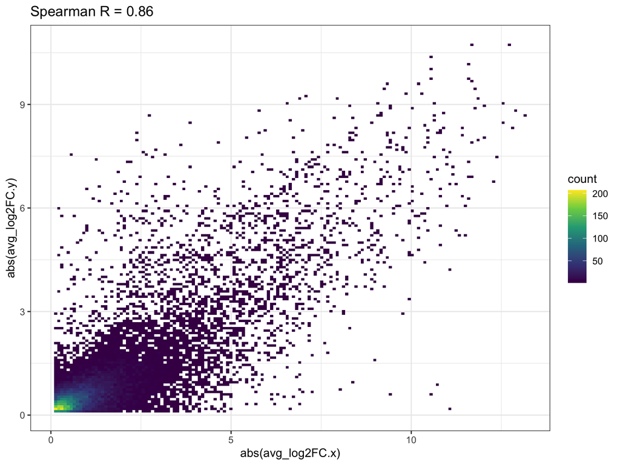

```r
ggplot(markers, aes(x=abs(avg_log2FC.x), y=abs(avg_log2FC.y)) ) +
  geom_bin2d(bins = 150, drop= T) +
  scale_fill_continuous(type = "viridis") +
  theme_bw()+
  ggtitle(paste0('Spearman R = ', round(cor(markers$avg_log2FC.x,
              markers$avg_log2FC.y), 2)
              ))
```

#### Integration.

We integrate the both dataset and calculate a miLISI score.

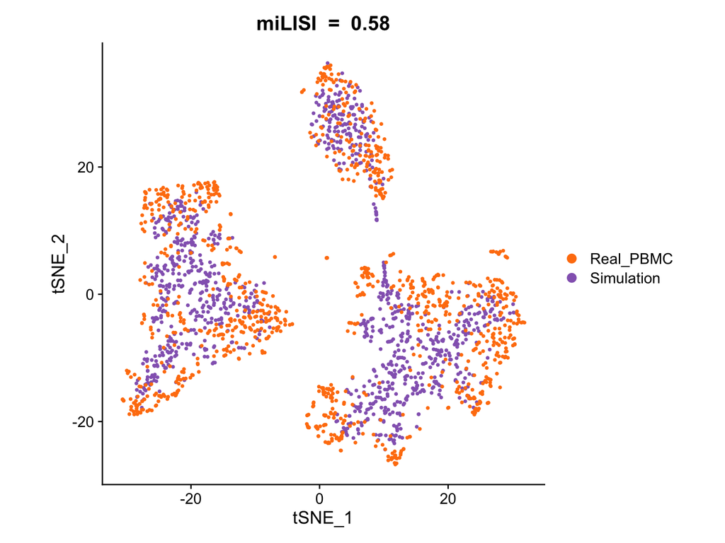

```r
DimPlot.integ(integrated.Sobj, "tsne")
```